# S4. Landmark and semi-landmarks used in ‘Characterizing the body morphology of the first metacarpal in the Homininae using 3D geometric morphometrics’

Thomas A. Püschel

03/03/2021

Paper authors: **Jonathan Morley, Ana Bucchi, Carlos Lorenzo, Thomas A. Püschel** Link to [preprint](https://doi.org/https://doi.org/10.1101/2020.04.30.070326)

> Corresponding author: Thomas A. Püschel Contact: Email: thomas.puschelrouliez@anthro.ox.ac.uk Web: [thomas.puschel.com](https://www.thomaspuschel.com/)

# Landmark collection

3D landmarks were collected to quantify the MC1’s morphology. Eight curves comprising 20 equidistant landmarks each were placed at pre-defined points on the MC1 (Figure 1). These landmarks were chosen to provide a good representation of the shaft of the bone. The first and last landmarks from each one of the eight curves were treated as fixed (i.e., 16 fixed landmarks), whereas all the rest of them (i.e., 144 landmarks) were considered as semi-landmarks.

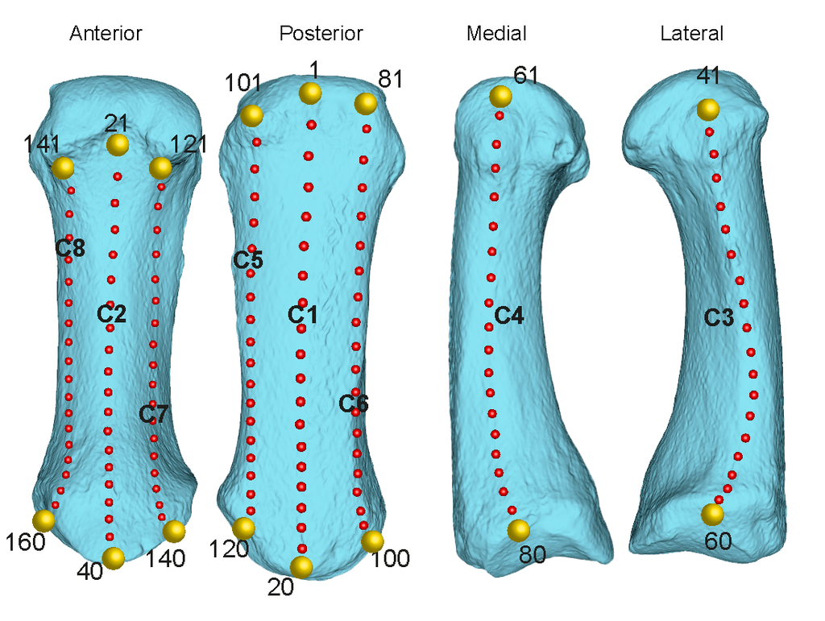

Figure 1. Illustration of the 16 landmarks (yellow spheres) and 144 semi-landmarks (red spheres) used in this study. The numbers of the 16 fixed landmarks and eight semi-landmark curves (C1-C8) are also plotted

# Landmark and semi-landmark definitions

[output not shown]

# Visualize landmarks and semi-landmarks

The model closest to the mean shape was previously warped to match the multivariate mean using the thin plate spline method. The landmarks and semi-landmarks are plotted on the surface of this average 3D model. The 16 fixed landmarks correspond to the yellow spheres, whereas the 144 semi-landmarks correspond to the smaller red spheres. Please notice that the 3D model was decimated to an extremely small size (as compared to our original models) to avoid long computational times when rendering with `rgl`.

[interactive chart not shown]